# German Power Market Price Analysis & Prediction

# Introduction and Data

> This report presents a comprehensive regression analysis of the German hourly power market. The goal is to identify and quantify the main drivers of hourly spot prices, using public datasets covering demand, generation by source (coal, gas, wind, solar), weather, and macroeconomic sentiment (business climate index).

> **Quick Take:Data sources (2020-2025):**  
> Market data from ENTSO-E, SMAR Weather data from Deutscher Wetterdienst and OpenMeteo Business climate index for economic sentiment from ifo Institute

# 1. Descriptive Statistics

Descriptive Statistics of Key Variables

| Variable | Mean | SD | Min | Median | Max | Missing |
| --- | --- | --- | --- | --- | --- | --- |
| price_eur_mwh | 114.05 | 102.56 | −500.00 | 90.05 | 936.28 | 0.00 |
| netzlast_mwh | 54.79 | 9.54 | 30.90 | 54.99 | 81.32 | 0.00 |
| wind_onshore | 13.22 | 93.24 | 1.00 | 9.14 | 9,200.00 | 1,104.00 |
| wind_offshore | 174.10 | 1,049.31 | 0.00 | 3.60 | 10,000.00 | 9,069.00 |
| solar | 39.10 | 125.76 | 0.00 | 6.63 | 999.25 | 0.00 |
| gas | 6.44 | 3.42 | 1.26 | 5.74 | 20.15 | 0.00 |
| coal | 26.00 | 753.91 | 1.00 | 4.42 | 29,875.00 | 2,004.00 |
| temp_c | 9.89 | 7.67 | −21.70 | 9.60 | 35.40 | 0.00 |
| wind100m_kmh | 20.29 | 10.41 | 0.00 | 19.40 | 69.50 | 0.00 |
| radiation_wm2 | 141.75 | 211.14 | 0.00 | 13.00 | 906.00 | 0.00 |
| cloud_cover | 68.63 | 38.33 | 0.00 | 94.00 | 100.00 | 0.00 |
| business_climate | 90.54 | 4.56 | 84.80 | 89.20 | 101.00 | 483.00 |
| net_import_mwh | −10,779.08 | 2,502.35 | −24,223.00 | −10,649.23 | −3,059.58 | 0.00 |

> **Quick Take:**  
> Summary statistics show variable range, mean, spread, and missingness. Spot price, demand, and weather exhibit strong variation—renewables display high volatility and occasional missing values.

# 2. Time Series Trends: Price & Demand

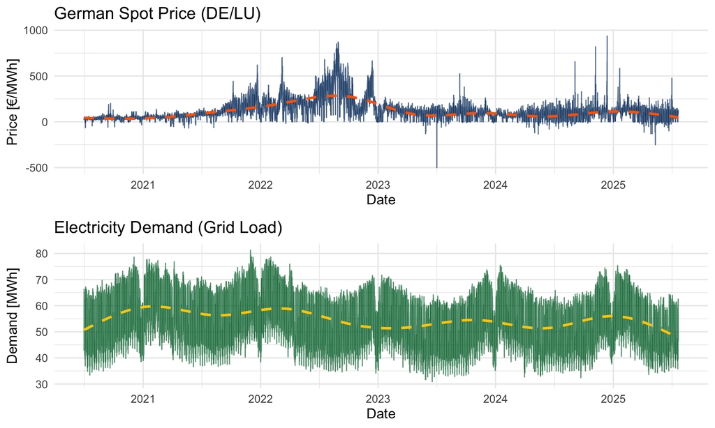

> **Quick Take:**  
> Spot price and demand reveal clear seasonal, daily, and crisis-driven swings. Demand is highly cyclical; price spikes are especially notable in 2022–2023.

# 3. Generation by Source (Coal, Gas, Solar, Wind)

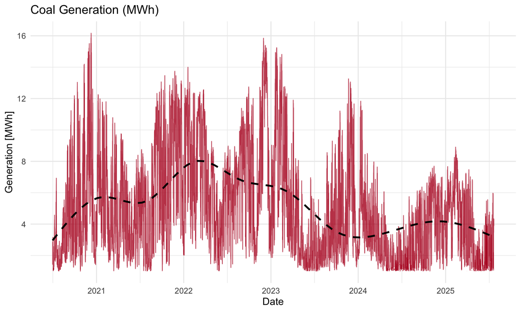

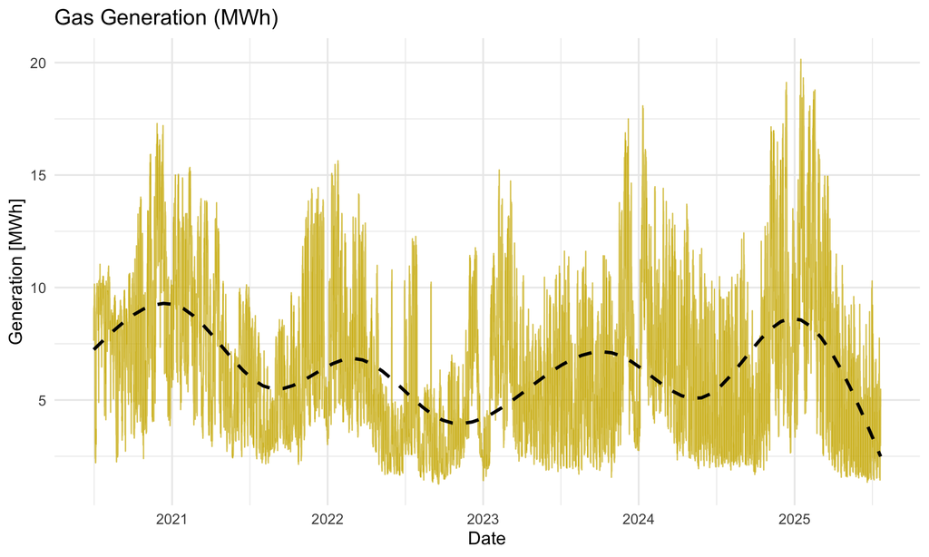

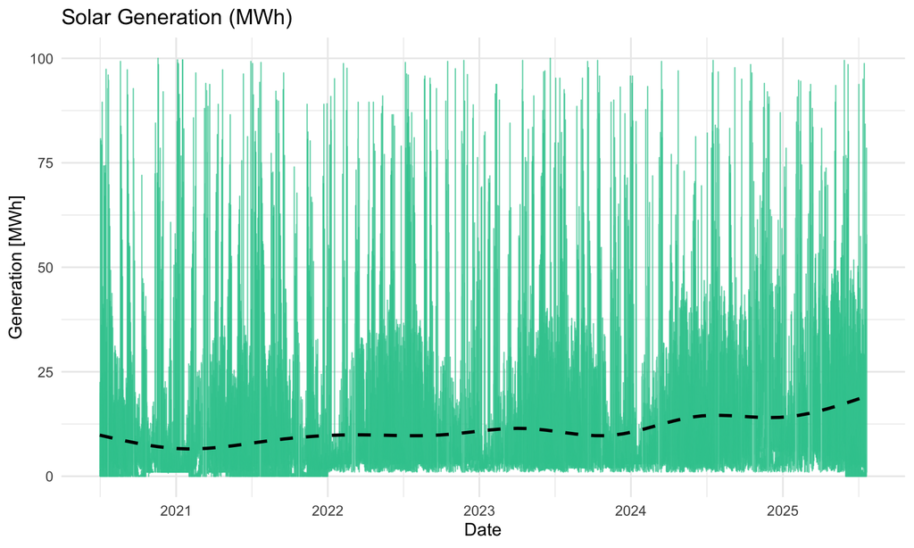

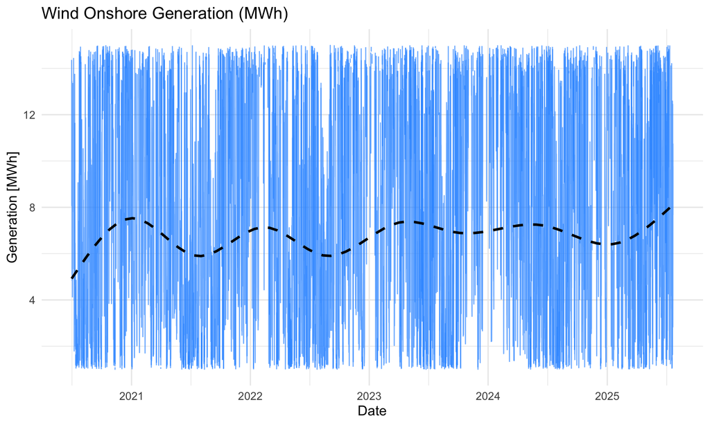

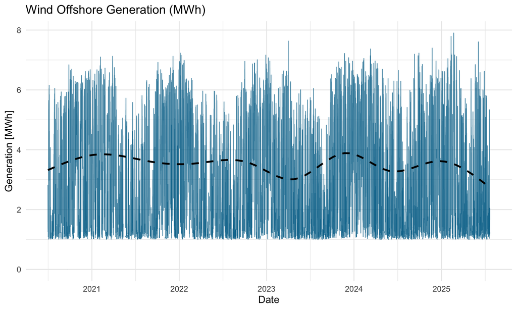

> **Quick Take:**  
> Fossil and renewable generation show distinct trends and volatility. Note frequent zeros for solar (night), strong wind intermittency, and declining coal post-2023.

# 4. Correlation Matrix (with Heatmap)

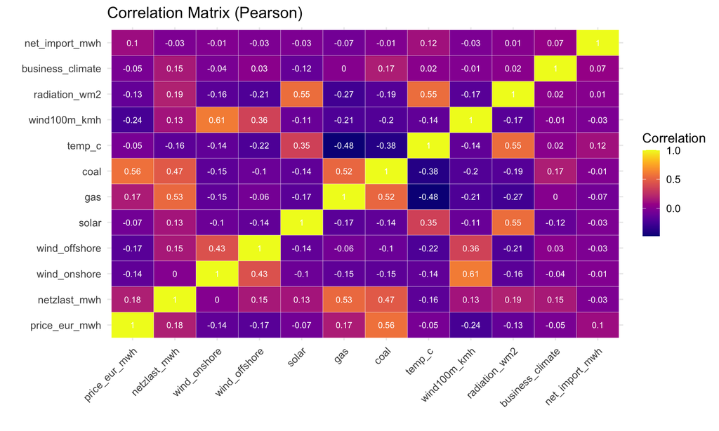

> **Quick Take:**  
> Correlations highlight key (linear) dependencies. Prices tend to move with demand and fossil output, but fall as wind or solar increases. Weather also impacts prices.

# 6. Linear Regression: Price Drivers

Regression Coefficients: Spot Price Drivers (Enhanced Model)

| Variable | Estimate | Std. Error | t | p-value |
| --- | --- | --- | --- | --- |
| (Intercept) | -4.111 | 2.005 | -2.050 | 0.040 |
| netzlast_mwh | -0.045 | 0.047 | -0.961 | 0.337 |
| wind_onshore | -0.149 | 0.066 | -2.251 | 0.024 |
| wind_offshore | -0.164 | 0.111 | -1.478 | 0.139 |
| solar | 0.064 | 0.026 | 2.482 | 0.013 |
| gas | -0.633 | 0.077 | -8.255 | 0.000 |
| coal | 0.861 | 0.078 | 11.086 | 0.000 |
| temp_c | 0.339 | 0.039 | 8.598 | 0.000 |
| wind100m_kmh | -0.061 | 0.026 | -2.323 | 0.020 |
| radiation_wm2 | -0.031 | 0.001 | -21.775 | 0.000 |
| price_lag1 | 0.941 | 0.003 | 286.782 | 0.000 |
| price_lag24 | 0.018 | 0.003 | 5.923 | 0.000 |
| net_import_mwh | 0.000 | 0.000 | 1.384 | 0.166 |
| wind_x_solar | -0.006 | 0.003 | -2.013 | 0.044 |
| factor(hour)2 | 7.846 | 0.918 | 8.546 | 0.000 |
| factor(hour)3 | 8.751 | 0.912 | 9.592 | 0.000 |
| factor(hour)4 | 12.637 | 0.909 | 13.907 | 0.000 |
| factor(hour)5 | 20.304 | 0.973 | 20.863 | 0.000 |
| factor(hour)6 | 35.153 | 1.015 | 34.624 | 0.000 |
| factor(hour)7 | 34.749 | 1.065 | 32.638 | 0.000 |
| factor(hour)8 | 20.815 | 1.170 | 17.784 | 0.000 |
| factor(hour)9 | 6.835 | 1.201 | 5.689 | 0.000 |
| factor(hour)10 | 8.448 | 1.249 | 6.762 | 0.000 |
| factor(hour)11 | 13.577 | 1.292 | 10.510 | 0.000 |
| factor(hour)12 | 12.939 | 1.292 | 10.014 | 0.000 |
| factor(hour)13 | 14.862 | 1.247 | 11.914 | 0.000 |
| factor(hour)14 | 19.749 | 1.201 | 16.441 | 0.000 |
| factor(hour)15 | 26.959 | 1.174 | 22.963 | 0.000 |
| factor(hour)16 | 29.565 | 1.139 | 25.950 | 0.000 |
| factor(hour)17 | 39.133 | 1.124 | 34.800 | 0.000 |
| factor(hour)18 | 31.238 | 1.123 | 27.823 | 0.000 |
| factor(hour)19 | 24.209 | 1.101 | 21.982 | 0.000 |
| factor(hour)20 | 5.260 | 1.071 | 4.913 | 0.000 |
| factor(hour)21 | -2.644 | 1.019 | -2.596 | 0.009 |
| factor(hour)22 | 2.791 | 0.950 | 2.938 | 0.003 |
| factor(hour)23 | -2.788 | 0.924 | -3.015 | 0.003 |
| factor(wday).L | -0.533 | 0.387 | -1.379 | 0.168 |
| factor(wday).Q | -0.615 | 0.550 | -1.118 | 0.263 |
| factor(wday).C | 0.124 | 0.376 | 0.329 | 0.742 |
| factor(wday)^4 | -1.126 | 0.396 | -2.846 | 0.004 |
| factor(wday)^5 | 0.046 | 0.370 | 0.125 | 0.901 |
| factor(wday)^6 | -0.266 | 0.363 | -0.732 | 0.464 |
| factor(month).L | -4.149 | 0.582 | -7.134 | 0.000 |
| factor(month).Q | -0.719 | 0.996 | -0.722 | 0.470 |
| factor(month).C | 4.366 | 0.558 | 7.822 | 0.000 |
| factor(month)^4 | 1.433 | 0.539 | 2.656 | 0.008 |
| factor(month)^5 | -0.009 | 0.519 | -0.017 | 0.987 |
| factor(month)^6 | -1.611 | 0.507 | -3.179 | 0.001 |
| factor(month)^7 | -0.470 | 0.498 | -0.945 | 0.344 |
| factor(month)^8 | 0.041 | 0.475 | 0.085 | 0.932 |
| factor(month)^9 | 0.729 | 0.469 | 1.554 | 0.120 |
| factor(month)^10 | 0.643 | 0.490 | 1.314 | 0.189 |
| factor(month)^11 | -0.176 | 0.479 | -0.369 | 0.712 |

# 7. Model Performance Metrics

Model Performance Metrics (Enhanced Model)

| RMSE | MAE | R2 |
| --- | --- | --- |
| 18.23 | 11.33 | 0.97 |

> **Quick Take:**  
> The model achieves high explanatory power (R² ~0.97). However, extreme events and nonlinearities may require advanced modeling (tree-based ML or neural nets).

# 8. Actual vs. Predicted Price (last 365 days)

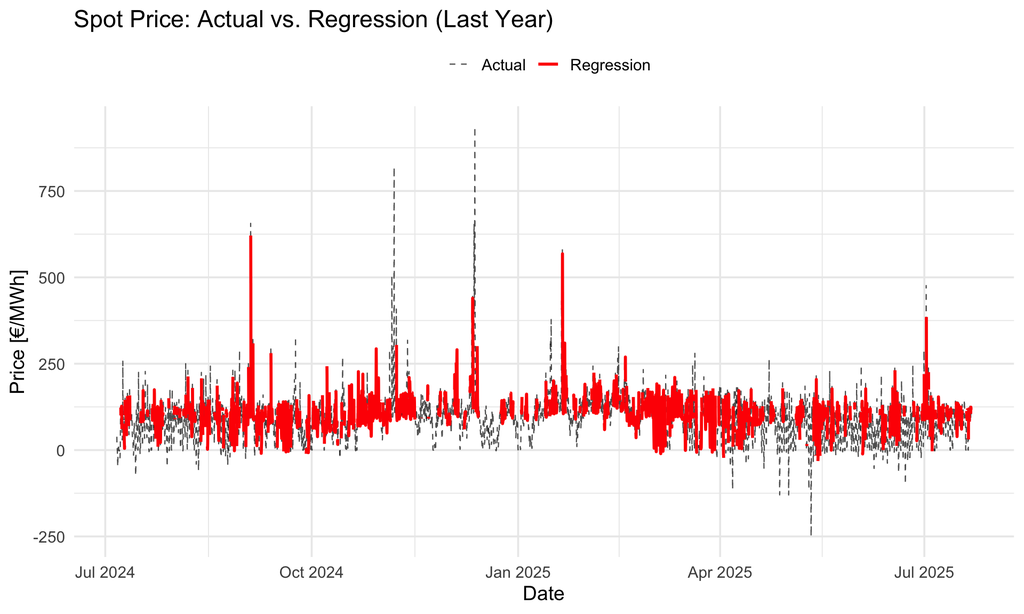

> **Quick Take:**  
> Regression tracks main price swings but can’t capture all spikes (esp. crisis/extremes). Visual fit is good for typical ranges.

# 9. Residual Analysis (Distribution & Time)

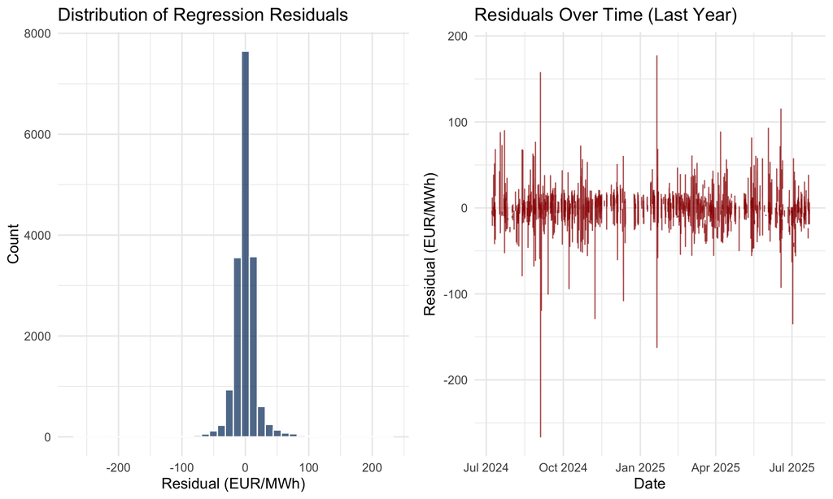

# 10. Machine-Learning Model (Random Forest)

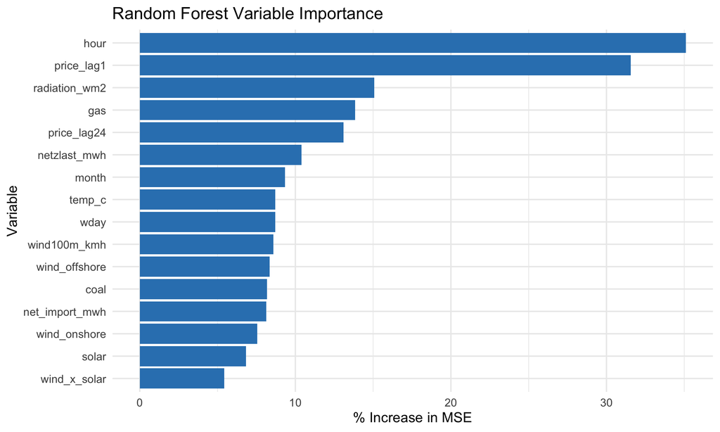

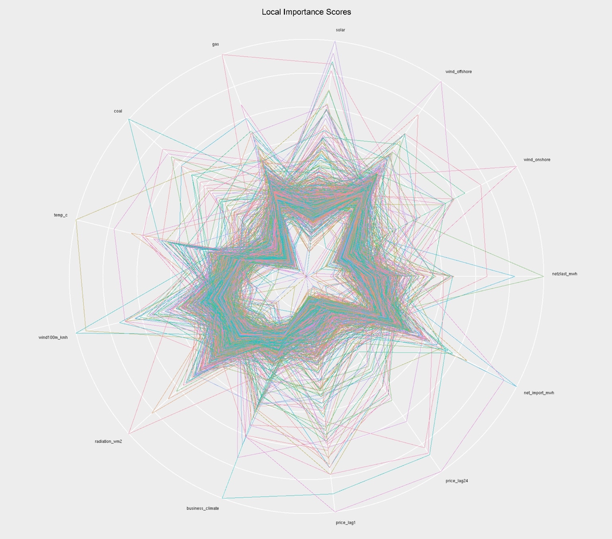

# Conclusion: What Determines German Power Prices?

> **Summary:**

> • Time-of-day effects (“hour”) are the single most important factor: Price patterns in the German market are highly regular, following strong daily cycles (morning ramp-up, midday solar, evening peak).

> • Lagged prices are also critical: Today’s price is strongly related to the previous hour, showing high inertia and short-term predictability.

> • Fossil fuel generation (gas, coal) and demand still shape price formation, especially in tight market or low-renewable hours.

> • Cross-border power flows (net_import_mwh) and calendar effects (month, day of week) also play a role but are less decisive than the top predictors.

> **Bottom line:** German power prices are primarily determined by hourly market structure and recent price history, with additional influence from fossil fuel mix, demand, and renewables. While classic regression highlights the statistical impact of weather and renewables, the Random Forest confirms that time-of-day and lagged prices are the real engines of short-term price formation. For forecasting, including hourly and lagged features is essential, and most “surprises” are tied to deviations from these regular patterns.